# Notebook

| Name | ANR |
| --- | --- |
| Freek van der Hulst | 928848 |
| Hidde Kienstra | 902873 |

### Question

In this notebook, we examine the price structure within two-sided markets. In this particular case, we look at the Dutch housing platform website [Funda](http://www.funda.nl). The main question we would like to answer is: how should the optimal price structure be set in this market?

### Motivation

During the seminar *Competition Policy*, we got our attention to this specific topic. In academic literature, theory on two-sided markets is still relatively new.

Standard economic theory would assume that prices below cost can never be efficient, however in a two-sided market this does not necessarily hold. If a platform like Funda wants to get both buyers and sellers on board, then it might be optimal to set a price below cost or even below zero. This is especially relevant for competition authorities in the case when they have to decide on a case with a possible market failure or abuse of a dominant position.

### Method

As a starting point for our research, we take the model that is introduced by [Armstrong (2002)](http://faculty.haas.berkeley.edu/hermalin/armstrong.pdf), in which the workings of a two-sided market are explained with the example of a nightclub.

Funda, or the market for house offer platforms in general, can be classified as a two-sided market, since there is a cross-side indirect network effect between buyers and sellers. Both parties exert a positive externality over each other, since the more real estate brokers join the platform, the more attractive it is for buyers to use it, and vice versa. Following this, what is often seen is that there is cross-subsidization between buyers and sellers. In practice, this means that in the case of Funda, the platform charges a seller fee to the real estate brokers, whereas buyers can make use of the website for free (see Figure 1).

Figure 1

[figure not shown]

### Answer

Before constructing our model, we first import the relevant libraries:

```python
from scipy import optimize,arange
from numpy import array
from sympy import *
import matplotlib.pyplot as plt
import numpy as np
%matplotlib inline
```

### Model

There are two groups of consumers: group 1 (real estate brokers) and 2 (house buyers), which are represented by $n_1$ and $n_2$, respectively. Their utilities are given by $u_1 = a_1n_2-p_1$ and $u_2 = 1-p_2$ with $a_1 > 0$. For simplicity, we assume that the number of consumers $n_i$ are equal to the groups' utilities, such that $n_1 = u_1$ and $n_2 = u_2$, and that only group 1's utility is dependent on the number of consumers on the other side. We think that is a reasonable assumption, since for brokers, it is harder to be active on multiple platform simultanuously compared to house buyers; for the latter, visiting multiple websites is not too costly.

#### Platform's profits

Focusing our attention on the platform, we assume that it incurs a cost $f_i$ per consumer in group $i$. Hence, the monopoly profit of the platform becomes $\pi_m = n_1(p_1 - f_1) + n_2(p_2 - f_2)$.

```python
def mp(p1,p2):
    return u1(p1)*(p1-f1)+u2(p2)*(p2-f2)

def u1(p1): return a1*(n2(u2))-p1

def u2(p2): return 1-p2

def n1(u1): return u1(p1)

def n2(u2): return u2(p2)
```

We assume that $f_1 = 3$ and $f_2 = 1$, since for the platform the services provided to brokers are more costly than for visitors of the website. For instance, advertisements for house offers have to be manually created. Below, we compute the first-order conditions by taking the derivative of monopoly profits $\pi_m$ with respect to $p_1$ and $p_2$. Following this, we solve the obtained equations.

```python
f1 = 3
f2 = 1
p1,p2,a1 = symbols('p1,p2,a1')

mp = mp(p1,p2)
dmpdp1 = mp.diff(p1)
dmpdp1
```

```
a1*(-p2 + 1) - 2*p1 + 3
```

```python
dmpdp2 = mp.diff(p2)
dmpdp2
```

```
-a1*(p1 - 3) - 2*p2 + 2
```

```python
solve((a1*(-p2 + 1) - 2*p1 + 3, -a1*(p1 - 3) - 2*p2 + 2), p1,p2)
```

```
{p1: 3*(a1**2 - 2)/(a1**2 - 4), p2: (a1**2 - 3*a1 - 4)/(a1**2 - 4)}
```

Below, we show the optimal prices $p_1$ and $p_2$ for a range of different values of $a_1$.

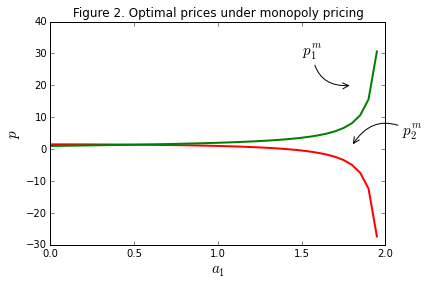

```python
def p1(a1):
    return 3*(a1**2 - 2)/(a1**2 - 4)

def p2(a1):
    return (a1**2 - 3*a1 - 4)/(a1**2 - 4)

range_a1 = arange(0.0,2.01,0.05)
range_p1 = [p1(a1) for a1 in range_a1]
range_p2 = [p2(a1) for a1 in range_a1]

plt.clf()
plt.plot(range_a1, range_p1,'-', color = 'r', linewidth = 2)
plt.plot(range_a1, range_p2,'-', color = 'g', linewidth = 2)
plt.title("Figure 2. Optimal prices under monopoly pricing",fontsize = 12)
plt.xlabel("$a_1$",fontsize = 15)
plt.ylabel("$p$",fontsize = 15,rotation = 90)
plt.annotate('$p^m_1$', xy=(1.8,20),  xycoords='data',
              xytext=(-50, 30), textcoords='offset points', size = 15,
              arrowprops=dict(arrowstyle="->", linewidth = 1,
                              connectionstyle="arc3,rad=.5"),
              )
plt.annotate('$p^m_2$', xy=(1.8,1),  xycoords='data',
              xytext=(50, 10), textcoords='offset points', size = 15,
              arrowprops=dict(arrowstyle="->", linewidth = 1,
                              connectionstyle="arc3,rad=.5"),
              )
```

#### Social welfare

Since we look from the perspective of the regulator (or CA), we aim on setting a price structure such that social welfare is maximized. Therefore, besides the platform's profits, we include consumer surplus, which we assume is equal to $v_i = u_i - p_i$. Social welfare is then defined by $W = \pi_m(u_1,u_2) + v_1(u_1) + v_2(u_2)$ in terms of utility. After defining the social welfare function, we perform the same steps as in the previous part when computing the monopoly prices.

```python
def W(p1,p2):
    return u1(p1)*(p1-f1)+u2(p2)*(p2-f2)+(u1(p1)-p1)+(u2(p2)-p2)

f1 = 3
f2 = 1
p1,p2,a1 = symbols('p1,p2,a1')

W = W(p1,p2)
dWdp1 = W.diff(p1)
dWdp1
```

```
a1*(-p2 + 1) - 2*p1 + 1
```

```python
dWdp2 = W.diff(p2)
dWdp2
```

```
-a1*(p1 - 3) - a1 - 2*p2
```

```python
solve((a1*(-p2 + 1) - 2*p1 + 1, -a1*(p1 - 3) - a1 - 2*p2), p1,p2)
```

```
{p1: 2*(a1**2 - a1 - 1)/(a1**2 - 4), p2: a1*(a1 - 3)/(a1**2 - 4)}
```

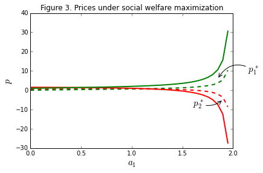

```python
def p1W(a1):
    return (2*(a1**2 - a1 - 1)/(a1**2 - 4))

def p2W(a1):
    return (a1*(a1 - 3)/(a1**2 - 4))

range_p1W = [p1W(a1) for a1 in range_a1]
range_p2W = [p2W(a1) for a1 in range_a1]

plt.clf()
plt.plot(range_a1, range_p1W,'--', color = 'r', linewidth = 2)
plt.plot(range_a1, range_p2W,'--', color = 'g', linewidth = 2)
plt.plot(range_a1, range_p1,'-', color = 'r', linewidth = 2)
plt.plot(range_a1, range_p2,'-', color = 'g', linewidth = 2)
plt.title("Figure 3. Prices under social welfare maximization",fontsize = 12)
plt.xlabel("$a_1$",fontsize = 15)
plt.ylabel("$p$",fontsize = 15,rotation = 90)
plt.annotate('$p^*_2$', xy=(1.9,-5),  xycoords='data',
              xytext=(-50, -10), textcoords='offset points', size = 15,
              arrowprops=dict(arrowstyle="->", linewidth = 1,
                              connectionstyle="arc3,rad=.3"),
              )
plt.annotate('$p^*_1$', xy=(1.85,6),  xycoords='data',
              xytext=(50, 10), textcoords='offset points', size = 15,
              arrowprops=dict(arrowstyle="->", linewidth = 1,
                              connectionstyle="arc3,rad=.5"),
              )
```

Hence, when determining the optimal price structure from a social point of view, there should be less cross-subsidization between buyers and sellers that are active on the platform.

### Discussion

What we have seen is that:

- A price below marginal cost does not necessarily mean that there is predatory pricing: setting a price structure in which one of the market sides pays a price below cost can be optimal, both when maximizing producer surplus and social welfare
- This shows that the price structure should not always reflect the marginal cost

In the ideal setting, we would have liked to include the cross-side externality for both market sides to make the model more representative of the actual market for house offer platforms.